# CERF data workup

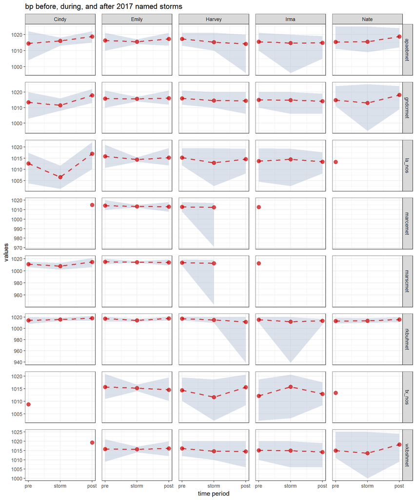

```r
metparam_grid("bp")
```

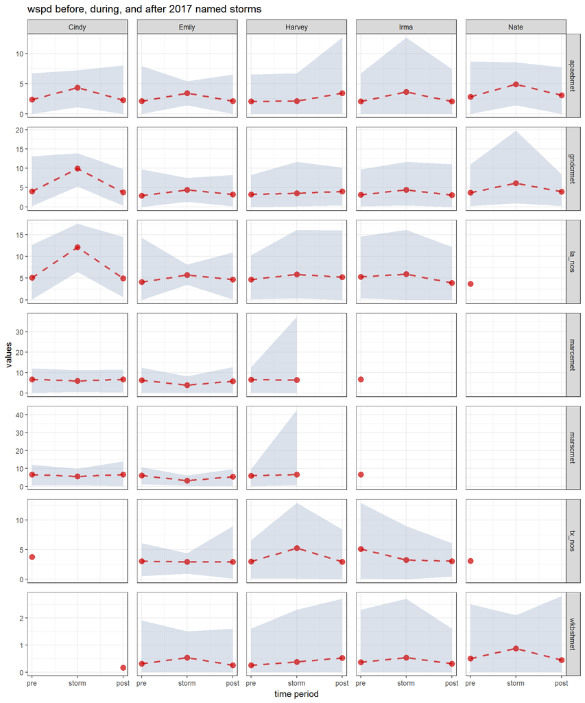

```r
metparam_grid("wspd")
```

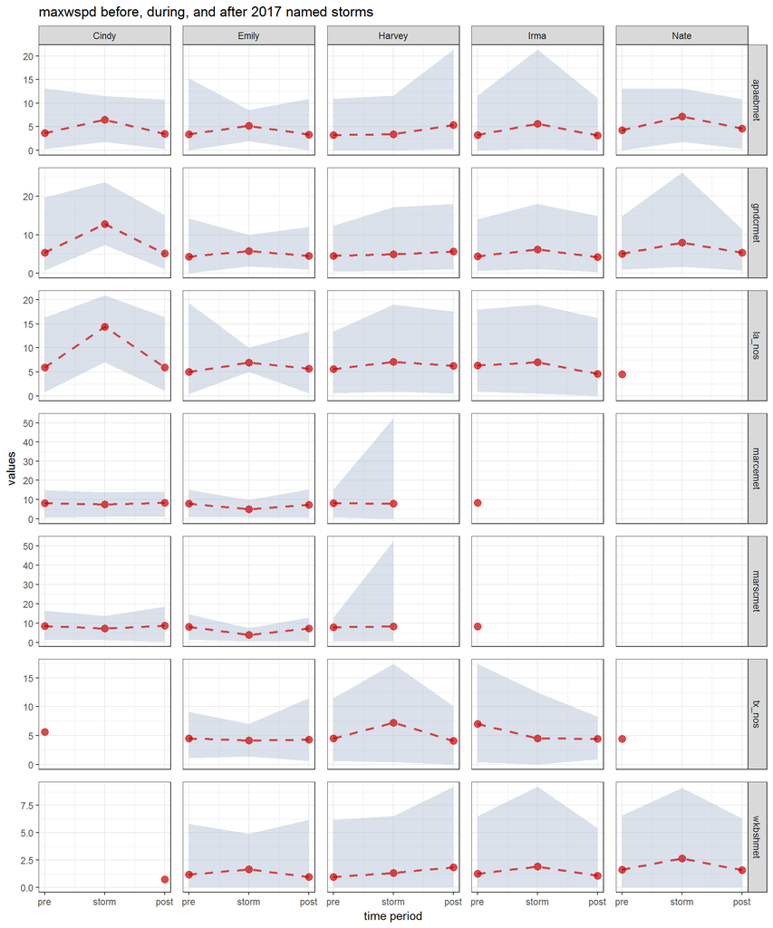

```r
metparam_grid("maxwspd")
```

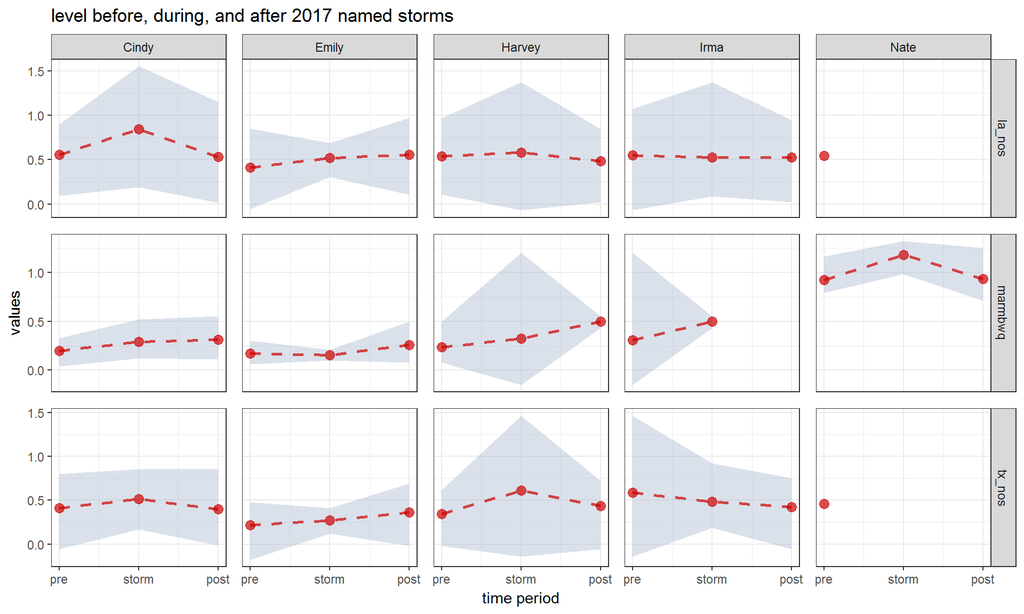

```r
wqribbon_grid("level")
```

### Ready the data for another script

I’ve decided to focus in on TS Cindy in the northern Gulf. We have plenty of conductivity/salinity data from those stations; one of them was discovered through IOOS; and the northern gulf stations were all impacted by her.

Because of the quantity of data that I ran through the process in this document, it’s pretty slow, so I’m going to generate a subset of data from these few stations to use in the deeper dive.

I’ve named the following NGOM stations and pulled all data until 9/1 from each:

- apadbwq
- apapcwq
- apaebmet
- gndbcwq
- gndblwq
- gndcrmet
- la_nos (this has both wq and met)
- wkbfrwq
- wkbwbwq
- wkbshmet

This has resulted in two data frames, one for wq and one for met, with all of the readings. I’ve saved those AND the table “storm info” into an .RData file called `dat_cindy_ngom`, which can be loaded into the next script.

```r
ngom_stns <- c("apadbwq", "apapcwq", "apaebmet", "gndbcwq", "gndblwq", "gndcrmet", "la_nos", "wkbfrwq", "wkbwbwq", "wkbshmet")

wq_cindy_ngom <- dat_wq %>%
    filter(stationcode %in% ngom_stns,
           datetimestamp < "2017-09-01 0:00")

met_cindy_ngom <- dat_met %>%
    filter(stationcode %in% ngom_stns,
           datetimestamp < "2017-09-01 0:00")

save(wq_cindy_ngom, met_cindy_ngom, storm_info, file="dat_cindy_ngom.R")
```

### Ready Irma data for another script

I think Irma had the widest impacts, so I’m going to check out her data. I will exclude Texas stations because of impacts from Harvey. We have plenty of conductivity/salinity data from those stations; one of them was discovered through IOOS; and the eastern and northern gulf stations were all impacted by her.

Because of the quantity of data that I ran through the process in this document, it’s pretty slow, so I’m going to generate a subset of data from these few stations to use in the deeper dive.

Irma was a named storm from 8/30-9/12.

I’ve named the following stations and pulled all data from from each from 8/1 to 10/12 (if available):

- apadbwq
- apapcwq
- apaebmet
- gndbcwq
- gndblwq
- gndcrmet
- la_nos (this has both wq and met)
- wkbfrwq
- wkbwbwq
- wkbshmet
- rkbfuwq
- rkbmbwq
- rkbuhmet

This has resulted in two data frames, one for wq and one for met, with all of the readings. I’ve saved those AND the table “storm info” into an .RData file called `dat_irma`, which can be loaded into the next script.

```r
stns <- c("apadbwq", "apapcwq", "apaebmet", "gndbcwq", "gndblwq", "gndcrmet", "la_nos", "wkbfrwq", "wkbwbwq", "wkbshmet", "rkbfuwq", "rkbmbwq", "rkbuhmet")

wq_irma <- dat_wq %>%
    filter(stationcode %in% stns,
           datetimestamp >= "2017-08-01 0:00",
           datetimestamp < "2017-10-13 0:00")

met_irma <- dat_met %>%
    filter(stationcode %in% stns,
           datetimestamp >= "2017-08-01 0:00",
           datetimestamp < "2017-10-13 0:00")

save(wq_irma, met_irma, storm_info, file="dat_irma.R")
```